# Homicides_Scandinavian

Lea Skriver Hansen

1/7/2022

*DISCLAIMER* this is not my first script with this data set. The first script went wrong and turned grey so i could not do anything with it so i had to delete it all and start over and that you can see in this new script

to be able to knit the final results i put # with the codes that did not work

#Introduction this script is my final results including my thoughts and some of the mistakes i made throughout the process

# Downloading the relevant packages for this project

```r
library(tidyverse)
```

```r
library(dplyr)
library(tidyr)
library(ggplot2)
library(readr)
library(readxl)
```

the readxl package was downloaded because of issues with csv files (that will be explained later in the script)

#downloading the data

```r
#data <- read_excel("Digitale_metoder_projekt/Homicide_Murder_Rate.xls")

#Homicide_Murder_Rates <- read_excel("data/Homicide_Murder_Rates.xls")
```

from previus classes i have learned that csv files does not work for me so i tried putting xls file in by code, but that also did not work so i had to put in in without the code by importing the data

#put the data in to ggplot failed attempt

```r
#head(Homicide_Murder_Rates)
```

```r
#head(Homicide_Murder_Rates)
```

to check if the data was correct

#first try

```r
#ggplot(data = Homicide_Murder_Rates) +
 #geom_line(mapping = aes(x= Year,
                         # y= Homicide_Murder_Rates$Per_100_k_DK, )) +
  #labs(x = "Year",
       #y = "Number of Murder per 100k",
       #title = "Murder Rate in Nothern Europe 1990-2018")
```

this was my first try to put it into ggplot but it said error

```r
#rlang::last_error()
```

trying to find out what the error was, but i could not figure it out

```r
#second try
#New_Homicide_Murder_Rates <- rename(Homicide_Murder_Rates,murder_per_100k = 'Murder rate in Nothern Europe (per 100,009)')
```

after looking at some of the things we have learned in class so i tried some of it but it still did not work

this was a try to see if i insertet one of the columns would work and it did but my goal is to get all the columns into a graphs so i can seperate them

```r
#ggplot(data = Homicide_Murder_Rates) +
  #geom_line(mapping = aes(x= Year,
                          #y= Per_100_k_DK, )) +
 # labs(x = "Year",
      # y = "Number of Murder per 100k",
      # title = "Murder Rate in Nothern Europe 1990-2018")
```

```r
#ggplot(data = Homicide_Murder_Rates) +
  #geom_line(mapping = aes(x = Year,
                          # y = Per_100_k_DK,
                          # color = Entity)) +
  #facet_wrap(~ Entity, nrow = 2) +
  #labs(x = "Year",
       #y = "Number of Murder per 100k ",
       #title = "Murder Rate in Nothern Europe 1990-2018")
```

trying to see if i could separate them but of course that did not work when i only had one country

```r
#Homicide_Murder_Rates <- rename(Homicide_Murder_Rates, number_of_Murders_per_100k=n)
```

again trying anything to see if it would work but it did not

#importing the new spreadsheet then i realized it was the spreadsheet that did not work and not just the code

```r
#Murder_rates_Notherneurope_1990-2018 <- read_csv("Murder_rates_northeurope_1990-2018.csv")

#Murder_rates_Notherneurope_1990_2018 <- read_csv("Murder_rates_Notherneurope_1990-2018.csv")

#getwd()

#Murder_rates_Notherneurope_1990_2018 <- read_csv("Murder_rates_Notherneurope_1990-2018.csv")
```

again the code gave me trouble so i put the csv file without the code and by importing it

#Checking the data is good to work with

```r
#head(Murder_rates_Notherneurope_1990_2018)
```

#prep the data for ggplot

```r
#ggplot(data = Murder_rates_Notherneurope_1990_2018) +
 # geom_line(mapping = aes(x= Year,
                         # y= Murder_per_100k, )) +
 # labs(x = "Year",
      # y = "Number of Murder per 100k",
      # title = "Murder Rate in Nothern Europe 1990-2018")
```

the data set in csv does not work, the data set is not separated probably so i have to use the xlsx file instead

```r
#Murder_rates_Notherneurope_1990_2018 <- read_excel("Homicides_Scandinavian/Murder_rates_Notherneurope_1990-2018.xlsx")

#getwd()

#Murder_rates_Notherneurope_1990_2018 <- read_excel("Murder_rates_Notherneurope_1990-2018.xlsx")
```

when trying to knit i had some issues because the data was importet and not by code so i tried using code

```r
Homicide_Murder_Rates <- read_excel("~/Desktop/Digitale metoder projekt /data/Homicide_Murder_Rates.xls")
```

the code could not show up because of the already existing one

```r
rm(Murder_rates_Notherneurope_1990_2018)
```

after removing the importet data set i used code to insert the data and it was a success

```r
Murder_rates_Notherneurope_1990_2018 <- read_excel("Murder_rates_Notherneurope_1990-2018.xlsx")
#View(Murder_rates_Notherneurope_1990_2018)
```

# putting the data into ggplot

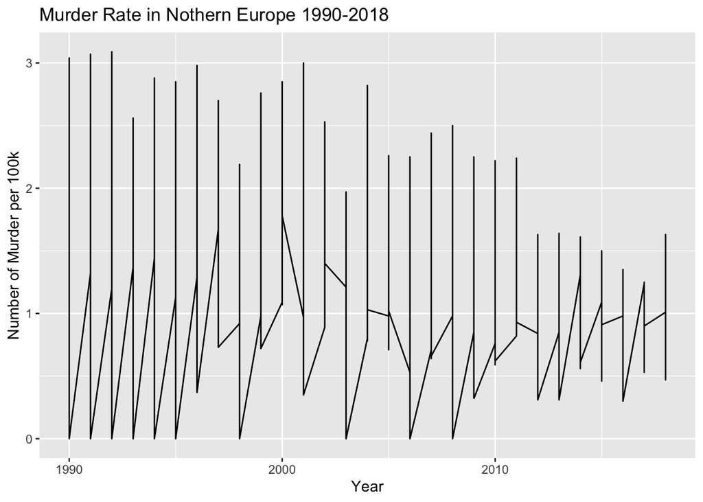

```r
ggplot(data = Murder_rates_Notherneurope_1990_2018) +
  geom_line(mapping = aes(x= Year,
                          y= Murder_per_100k, )) +
  labs(x = "Year",
       y = "Number of Murder per 100k",
       title = "Murder Rate in Nothern Europe 1990-2018")
```

# seperate them by country ¨

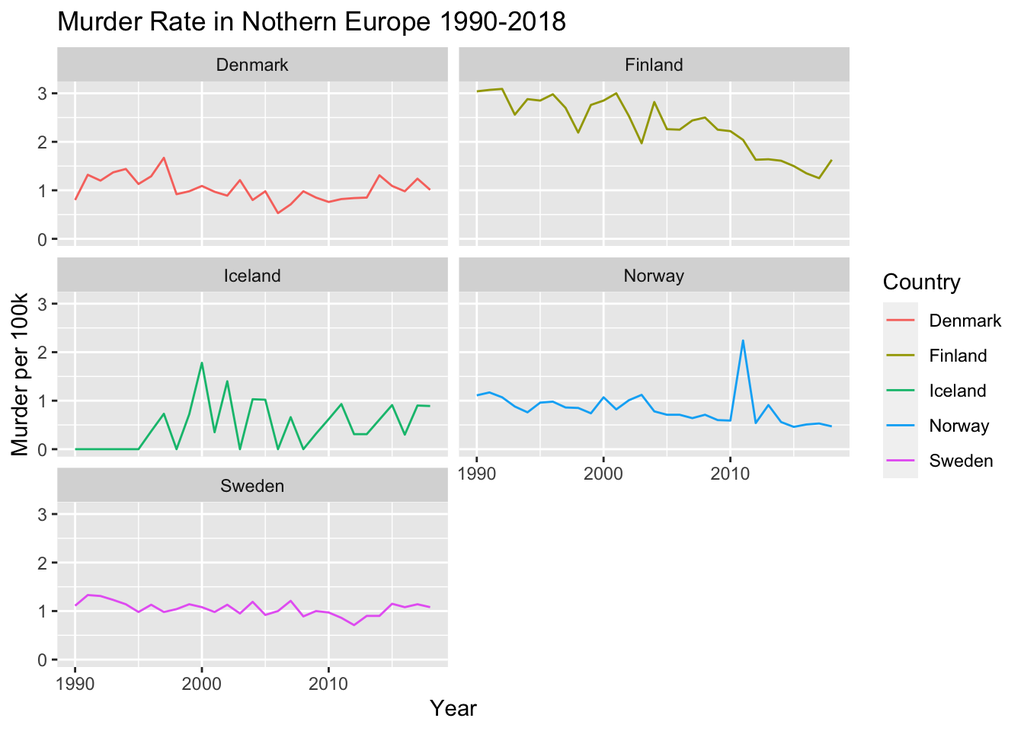

```r
ggplot(data = Murder_rates_Notherneurope_1990_2018) +
  geom_line(mapping = aes(x = Year,
                           y = Murder_rates_Notherneurope_1990_2018$Murder_per_100k,
                           color = Country)) +
  facet_wrap(~ Country, nrow = 3) +
  labs(x = "Year",
       y = "Murder per 100k",
       title = "Murder Rate in Nothern Europe 1990-2018")
```

#change layout

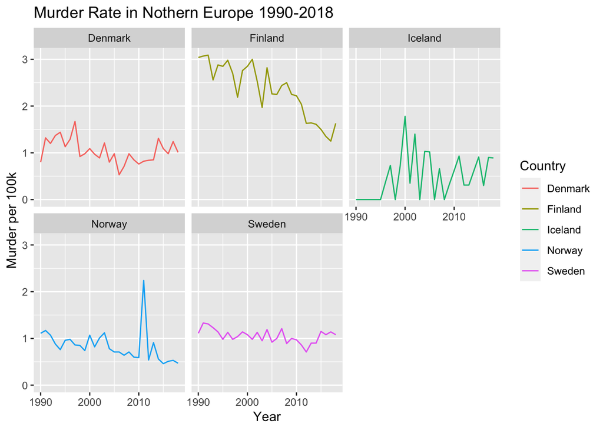

```r
ggplot(data = Murder_rates_Notherneurope_1990_2018) +
  geom_line(mapping = aes(x = Year,
                           y = Murder_rates_Notherneurope_1990_2018$Murder_per_100k,
                           color = Country)) +
  facet_wrap(~ Country, nrow = 2) +
  labs(x = "Year",
       y = "Murder per 100k",
       title = "Murder Rate in Nothern Europe 1990-2018")
```

#changing from geom_line to geom_bar #first try

```r
#Murder_rates_Notherneurope_1990_2018
#ggplot( aes(x=Murder_per_100k)) +
  #geom_bar()
```

this did not work because there was missing a chunk of code for it to work #second try

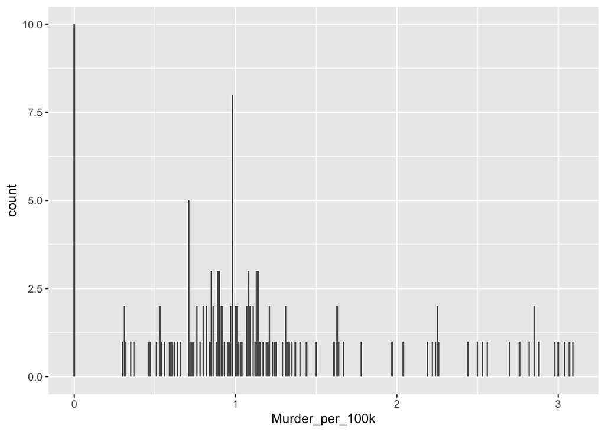

```r
Murder_rates_Notherneurope_1990_2018 %>%
  ggplot(aes(x = Murder_per_100k)) +
  geom_bar()
```

realising i was missing something and when i added that to the code it worked

#seperating them by country

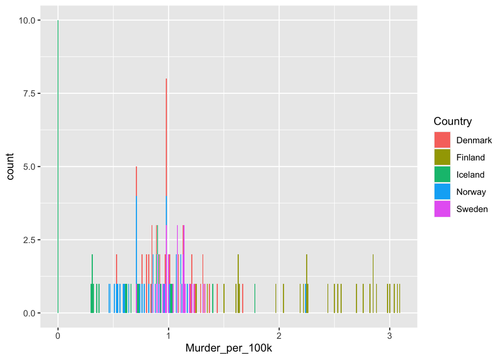

```r
Murder_rates_Notherneurope_1990_2018 %>%
  ggplot(aes(x = Murder_per_100k)) +
  geom_bar(aes(fill= Country))
```

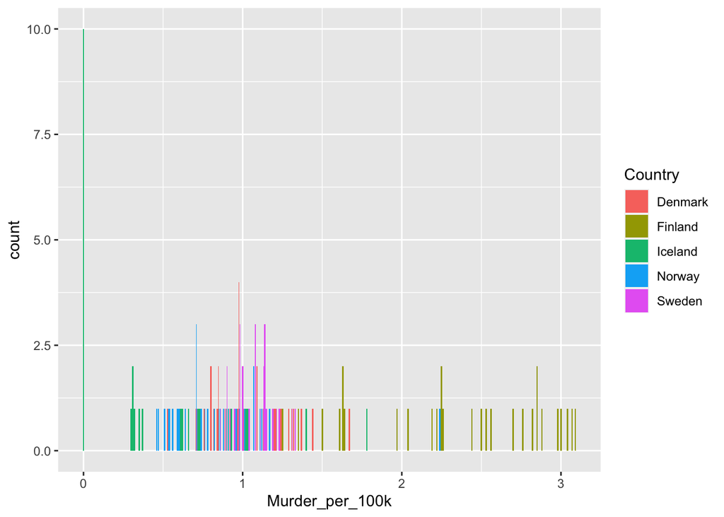

```r
Murder_rates_Notherneurope_1990_2018 %>%
  ggplot(aes(x = Murder_per_100k)) +
  geom_bar(aes(fill= Country), position = "dodge")
```

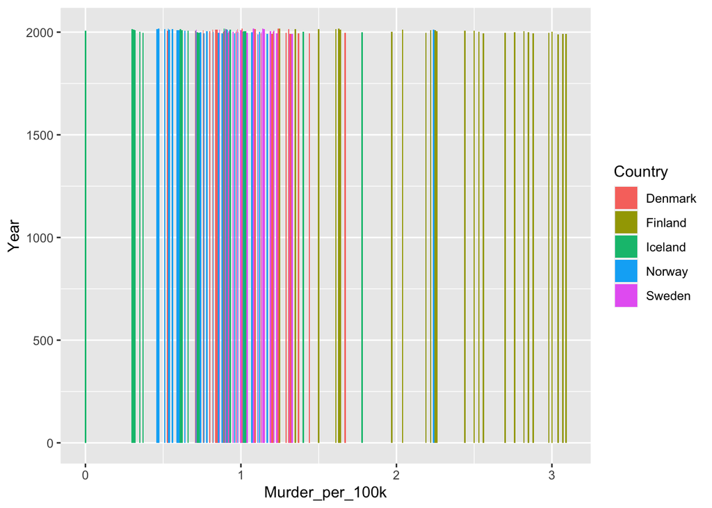

```r
Murder_rates_Notherneurope_1990_2018 %>%
  ggplot(aes(x = Murder_per_100k, y = Year, fill= Country)) +
  geom_bar(stat = "identity", position = "dodge")
```

her i was a bit confused because it did not look rigth

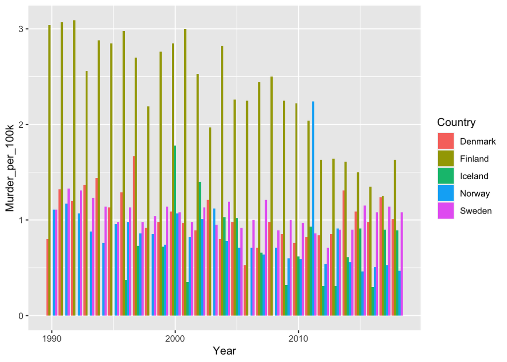

```r
Murder_rates_Notherneurope_1990_2018 %>%
  ggplot(aes(x = Year, y = Murder_per_100k, fill= Country)) +
  geom_bar(stat = "identity", position = "dodge")
```

then i realised that i had to switch the x and y and then it looked right

#seperating them so each country have its own graph

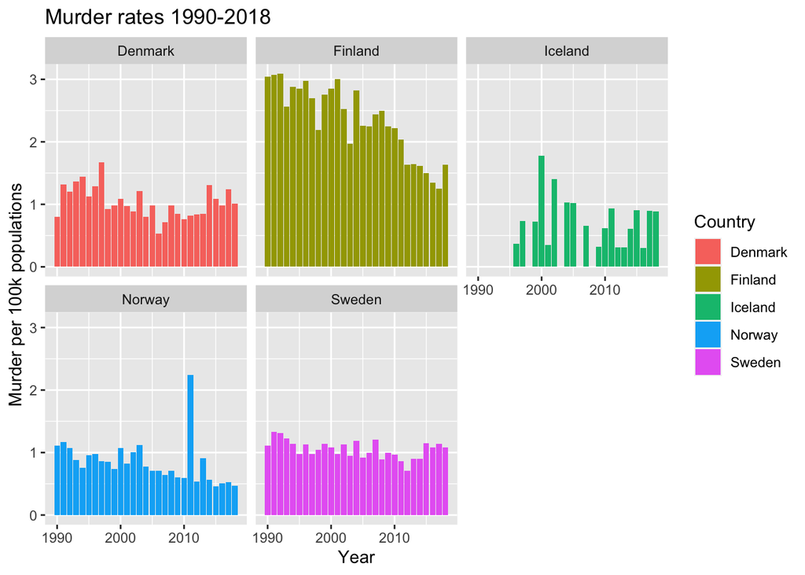

```r
Murder_rates_Notherneurope_1990_2018 %>%
  ggplot(aes(x = Year, y = Murder_per_100k, fill= Country)) +
  geom_bar(stat = "identity", position = "dodge") +
  labs( title = "Murder rates 1990-2018",
        x= "Year",
        y= "Murder per 100k populations") +
  facet_wrap(~ Country)
```

#find max in each country #Denmark

```r
Per_100_k_DK <-c(1.01,1.24,0.98,1.09,1.31,0.85,0.84,0.82,0.76,0.85,0.98,0.71,0.53,0.98,0.8,1.21,0.89,0.97,1.09,0.98,0.92,1.67,1.29,1.13,1.44,1.37,1.2,1.32,0.8)

class(Per_100_k_DK)
```

```
## [1] "numeric"
```

```r
max(Per_100_k_DK)
```

```
## [1] 1.67
```

#Norway

```r
Per_100_k_NO<-c(0.47,0.53,0.51,0.46,0.56,0.91,0.54,2.24,0.59,0.6,0.71,0.64,0.71,0.71,0.78,1.12,1.01,0.82,1.07,0.74,0.85,0.86,0.98,0.96,0.76,0.88,1.07,1.17,1.11)

class(Per_100_k_NO)
```

```
## [1] "numeric"
```

```r
max(Per_100_k_NO)
```

```
## [1] 2.24
```

#Sweden

```r
Per_100_k_SW<-c(1.08,1.14,1.08,1.15,0.9,0.9,0.71,0.86,0.97,1,0.89,1.21,1,0.92,1.19,0.95,1.13,0.98,1.08,1.14,1.04,0.98,1.12,0.98,1.14,1.23,1.31,1.33,1.11)

class(Per_100_k_SW)
```

```
## [1] "numeric"
```

```r
max(Per_100_k_SW)
```

```
## [1] 1.33
```

```r
max(Per_100_k_SW)
```

```
## [1] 1.33
```

#Finland

```r
Per_100_k_FI<-c(1.63,1.25,1.35,1.5,1.61,1.64,1.63,2.04,2.22,2.25,2.5,2.44,2.25,2.26,2.82,1.97,2.53,3,2.85,2.76,2.19,2.7,2.98,2.85,2.88,2.56,3.9,3.07,3.04)

class(Per_100_k_FI)
```

```
## [1] "numeric"
```

```r
max(Per_100_k_FI)
```

[output not shown]

#Iceland

```r
Per_100_k_IC<-c(0.89,0.9,0.3,0.91,0.61,0.31,0.31,0.93,0.62,0.32,0,1.02,1.03,0,1.4,0.35,1.78,0.72,0,0.73,0.37,0,0,0,0,0,0)

class(Per_100_k_IC)
```

```
## [1] "numeric"
```

```r
max(Per_100_k_IC)
```

```
## [1] 1.78
```

```r
max(Per_100_k_IC)
```

```
## [1] 1.78
```

```r
max(Per_100_k_IC)
```

```
## [1] 1.78
```

i had a bit of trouble to find the right max with the data form Iceland but there was a mistake in c() so when i fixed that i got the right one